# Typical Filipino

# Introduction

Filipinos are cheerful, resourceful and practical people. It is in our nature to make the best out a of any situation, no matter how hard it is. We get this from our strong family values and religious beliefs. However, our ideals are not always represented in our actions especially when it comes to our financial priorities. I would always hear stories of parents working abroad for 10 to 20 years and coming back to their families poorer than they were before they left.

## Objectives

In this article, I would like to find out if the spending habits and financial priorities change as thier income increases of a typical Filipino family.

## Dataset Source

This dataset is from The Philippine Statistics Authority who conducts the Family Income and Expediture Survey (FEIS) every 3 years nationwide. This is from the 2015 most recent survey. The raw data was cleaned by Francis Paul Flores from his [kaggle.com/grosvenpaul](https://www.kaggle.com/grosvenpaul/family-income-and-expenditure/downloads/Family%20Income%20and%20Expenditure.csv).

# Getting a Feel of the Data

The Dataset contains 41,544 observations of Filipino Households from every Region of the country. It is comprised of 60 variables describing each family on their income, family description and expenditure.

```r
library(readr)
fies <- read_csv("fies.csv")
# Rename Lables for easier reference.
names(fies) <- c("income", "region", "expense", "source",
                 "agri_house", "exp_bread", "exp_rice", "exp_meat",
                 "exp_seafood", "exp_fruit", "exp_veg", "exp_resto_hotel",
                 "exp_alcoh", "exp_taba", "exp_clothe", "exp_house_water",
                 "exp_rent", "exp_med", "exp_trans", "exp_comms",
                 "exp_edu", "exp_misc", "exp_spec", "exp_farm",
                 "inc_entrep", "head_gender", "head_age", "head_stat",
                 "head_educ", "head_job_bus", "head_occup", "head_workclass",
                 "family_t", "family_n", "kids_n", "young_n",
                 "employed_n", "house_t", "roof_t", "wall_t",
                 "house_area", "house_age", "bed_n", "house_tenure",
                 "toilet", "electric", "water_t", "tv_n",
                 "DVD_n", "sterio_n", "ref_n", "wash_n",
                 "aircon_n", "car_n", "tel_n", "cell_n",
                 "pc_n", "stove_n", "mboat_n", "mbike_n")
```

There are 60 variables in this dataset and are not code-friendly. First thing to do is rename each column key. A detailed desciption of each column is documented on a separate txt file for your reference.

```r
names(fies)
```

```
 [1] "income"          "region"          "expense"         "source"          "agri_house"      "exp_bread"
 [7] "exp_rice"        "exp_meat"        "exp_seafood"     "exp_fruit"       "exp_veg"         "exp_resto_hotel"
[13] "exp_alcoh"       "exp_taba"        "exp_clothe"      "exp_house_water" "exp_rent"        "exp_med"
[19] "exp_trans"       "exp_comms"       "exp_edu"         "exp_misc"        "exp_spec"        "exp_farm"
[25] "inc_entrep"      "head_gender"     "head_age"        "head_stat"       "head_educ"       "head_job_bus"
[31] "head_occup"      "head_workclass"  "family_t"        "family_n"        "kids_n"          "young_n"
[37] "employed_n"      "house_t"         "roof_t"          "wall_t"          "house_area"      "house_age"
[43] "bed_n"           "house_tenure"    "toilet"          "electric"        "water_t"         "tv_n"
[49] "DVD_n"           "sterio_n"        "ref_n"           "wash_n"          "aircon_n"        "car_n"
[55] "tel_n"           "cell_n"          "pc_n"            "stove_n"         "mboat_n"         "mbike_n"
```

## Income Distribution

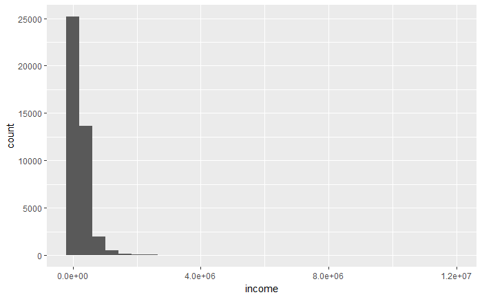

```r
summary(fies$income)
```

```
    Min.  1st Qu.   Median     Mean  3rd Qu.     Max.
   11285   104895   164080   247556   291138 11815988
```

Doing a quick summary of the income, we see that the average income of each household is 247,556 Php annually. But this is skewed because of the maximum income of 11 mill Php of the super rich.

## Why Averaging Everything is just Lazy

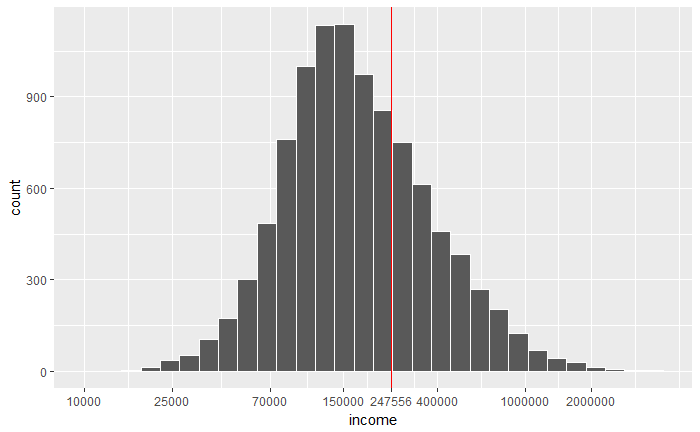

We transform the histogram to adjust the power of magnitude of each income and as a result we can see a beautiful normal distribution. To understand why we use log, imagine that we made the x axis points closer together so that we can see see the distribution more clearly.

The problem with relying on averages is that it is heavily influenced by outliers. Php 247,556 in the graph is far from the center, which makes it a poor representative of the distribution.

The Rich are really rich at 11 mill Php and the Poor are really poor with only 11,285 Php of annual income.

In addition, this average is of the whole population. We can’t do that because, for some people, 247k is small while other it is very big. So, we facet the graph according to different groups or work classes.

## Grouped by Working Class according to Survey

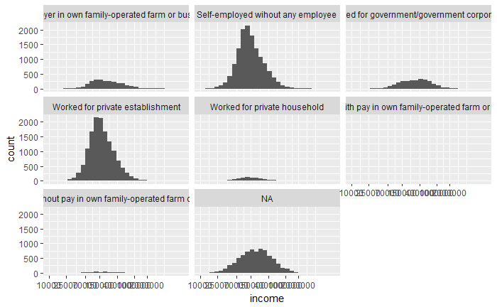

In this graph, we use the work class determined by the survey. But this is not really telling us anything especially that the categories are vague and are not familiar. The needs a little bit of cleaning.

## We make our own Groups

```r
library(stringr)
library(dplyr)
pro_class <- paste(c("managers", "medical", "dentist", "lawyer",
                     "architect", "supervisor", "trade", "education",
                     "chemist", "professionals", "scientist",
                     "justice", "Mechanical engineers", "director",
                     "accountant", "Chemical engineers",
                     "Electrical Engineers", "Industrial engineers",
                     "designer", "singers", "television", "dancer",
                     "fashion", "marketing", "Civil engineers", "air",
                     "Computer programmers", "nurse", "Librarians",
                     "science", "therapist", "opticians", "Veter",
                     "pilots", "estate agents", "plant operators"),
                   collapse = "|")
farm_class <- paste(c("farm", "fish", "growers", "gather", "duck",
                      "cultivat", "plant", "hunter", "village",
                      "practitioners", "healers", "diary", "animal"),
                    collapse = "|")
work_class <- paste(c("workers", "carpenters", "welder", "helper", "clean",
                      "launder", "labor", "driver", "freight", "mechanics",
                      "mason", "porter", "waiter", "cook", "foremen",
                      "caretaker", "lineman", "varnish", "conductor",
                      "salesperson", "bookkeeper", "inspector", "undertaker",
                      "loggers", "wood", "roofers", "cutter", "electricians",
                      "assembler", "builder", "metal",  "tanners", "garbage",
                      "repair", "prepare", "rigger", "vendors", "valuers",
                      "setters", "guides", "tasters", "potters"),
                    collapse = "|")
off_class <- paste(c("pawn", "buy", "baker", "maker", "tailor", "assistant",
                     "clerk", "engineering technicians", "operators",
                     "artists", "managers/managing proprietors", "insurance",
                     "educ", "principals", "secretaries", "general",
                     "pharmacists"),
                    collapse = "|")
fies$head_class <- with(fies,
                        ifelse(str_detect(head_workclass, "government"),
                               "gov",
                        ifelse(grepl(work_class, head_occup, ignore.case = T),
                               "work",
                        ifelse(grepl(off_class, head_occup, ignore.case = T),
                               "off",
                        ifelse(grepl(farm_class, head_occup, ignore.case = T),
                               "farm",
                        ifelse(grepl(pro_class, head_occup, ignore.case = T),
                               "pro",
                               NA))))))
```

## We got to Catch them All

```r
fies.occup <- fies %>%
  filter(is.na(fies$head_class)) %>%
  group_by(head_occup) %>%
  summarise(n= n(),
            income_mean = mean(income),
            income_median = median(income)) %>%
  arrange(desc(n))
fies.occup
```

```
# A tibble: 15 x 4
                                                                  head_occup     n income_mean income_median
                                                                      <fctr> <int>       <dbl>         <dbl>
 1                                                                      <NA>  7536    285650.6      201883.0
 2                            Technical and commercial sales representatives    12    615938.2      523042.0
 3                                  Electronics and communications engineers     6    540009.7      422666.0
 4                                                                 Draftsmen     5    459961.2      381394.0
 5                                                           Food preservers     5    178965.4      189194.0
 6                                   Silk-screen, block and textile printers     5    251989.6      232441.0
 7                                                       Electronics fitters     3    377631.7      184684.0
 8                             Technical and vocational instructors/trainors     3    565601.0      659465.0
 9                                         Travel consultants and organizers     3    456043.3      474100.0
10                                               Enlisted personnel n. e. c.     2    117844.5      117844.5
11 Senior officials of humanitarian and other special-interest organizations     2    321022.5      321022.5
12                                                     Companions and valets     1    595309.0      595309.0
13                                                     Legislative officials     1    859016.0      859016.0
14                                                   Shotfirers and blasters     1    203601.0      203601.0
15                                                            Staff officers     1    331029.0      331029.0
```

I decided to evaluate each occupation of the head of the family and manually group each household according to the following working class:

- *Professionals.* Jobs that usually requires higher education.
- *Office* Usually found in shops and offices of goods.
- *Government.* Jobs in government.
- *Workers.* Jobs that usually pays low and does not require a degree.
- *Farmers.* Jobs that pertains to rural work. Agriculture, Fishing, etc.

I am basing the categories based on my own classifications of how I see the working class and their overall mean income.

```r
tapply(fies$income, fies$head_class, summary)
```

```
$farm
   Min. 1st Qu.  Median    Mean 3rd Qu.    Max.
  12911   83998  119494  160549  178824 4810822

$gov
   Min. 1st Qu.  Median    Mean 3rd Qu.    Max.
  24886  174310  323632  426544  558545 3805717

$off
    Min.  1st Qu.   Median     Mean  3rd Qu.     Max.
   21136   134162   215718   316159   367331 11815988

$pro
   Min. 1st Qu.  Median    Mean 3rd Qu.    Max.
  25133  317914  520088  665344  836419 4208400

$work
   Min. 1st Qu.  Median    Mean 3rd Qu.    Max.
  11285  104104  150904  193838  232152 7082152
```

## A Millioniare Waiter

I review each working class and see what I can further refine. My goal is to segment as much as I can to emphasize the division among the working classes and at the same time being fair with my evaluation of the different jobs.

```r
fies.workers <- fies %>%
  filter(fies$head_class == "work") %>%
  select(head_occup, income, inc_entrep) %>%
  arrange(desc(income), head_occup)
fies.workers
```

| head_occup | income | inc_entrep |
| --- | --- | --- |
| Street ambulant vendors | 7082152 | 6576302 |
| Market and sidewalk stall vendors | 6203960 | 5749030 |
| Waiters, waitresses and bartenders | 5652261 | 5107451 |
| General managers/managing proprietors in personal care, cleaning and relative services | 2064100 | 885700 |
| Shop salespersons and demonstrators | 1912524 | 1569421 |
| Market and sidewalk stall vendors | 1885536 | 1085736 |
| Market and sidewalk stall vendors | 1800852 | 1748039 |
| Building caretakers | 1796730 | 0 |
| Production supervisors and general foremen | 1689442 | 1320500 |
| Shop salespersons and demonstrators | 1634854 | 73898 |

[output cut: 990 more lines]

```r
subset(fies.workers, income == "5652261")
```

| head_occup | income | inc_entrep |
| --- | --- | --- |
| Waiters, waitresses and bartenders | 5652261 | 5107451 |

I then checked the worker class and noticed some interesting outliers in the group. The one that stood out is a Waiter job who is earning Php5,652,261 annually. This does not seem right to me and I took a deeper look and found out that income is the sum of their income from their jobs and their business. Since we are categorizing each as income according to their working class, we re-evaluate by deriving the income from their jobs from their total income.

Subtracting the income from business from the total income, the Waiter was actually earning Php544,810 annually from his job and Php5,107,451 from his business.

## We just want the Income from their Jobs

```r
fies$inc_work <- with(fies, income - inc_entrep)
head(table(sort(fies$inc_work)))
```

```
  0 137 150 540 550 667
 22   1   1   1   1   1
```

```r
tapply(fies$inc_work, fies$head_class, summary)
```

```
$farm
   Min. 1st Qu.  Median    Mean 3rd Qu.    Max.
   1212   26991   54926   89381  103539 3034500

$gov
   Min. 1st Qu.  Median    Mean 3rd Qu.    Max.
  18370  147436  294358  387665  518604 3210933

$off
    Min.  1st Qu.   Median     Mean  3rd Qu.     Max.
       0    52627   119538   193280   244077 11639365

$pro
   Min. 1st Qu.  Median    Mean 3rd Qu.    Max.
   4339  287864  484082  599179  752761 3310612

$work
   Min. 1st Qu.  Median    Mean 3rd Qu.    Max.
      0   85870  130418  166019  203076 1796730
```

## Reveiwing the Professionals

```r
fies.pro <- fies %>%
  filter(fies$head_class == "pro") %>%
  group_by(head_occup) %>%
  summarise(income_mean = mean(inc_work),
            income_median = median(inc_work),
            n= n()) %>%
  arrange(desc(income_mean))
fies.pro
```

| head_occup | income_mean | income_median | n |
| --- | --- | --- | --- |
| Agronomists and related scientists | 2155298.0 | 2155298.0 | 1 |
| Aircraft pilots, navigators and flight engineers | 2089931.0 | 2089931.0 | 1 |
| Lawyers | 1295705.1 | 1147420.0 | 11 |
| Directors and chief executives of corporations | 1271361.2 | 861047.5 | 20 |
| Chemical engineers | 1207281.3 | 1168320.0 | 3 |
| Justices | 1201001.0 | 1201001.0 | 1 |
| Medical doctors | 1090998.1 | 880310.0 | 10 |
| Production and operations managers in transport, storage and communications | 1079478.3 | 909099.0 | 10 |
| Maritime transport service supervisors | 1037387.0 | 1037387.0 | 1 |
| Mechanical engineers | 914181.9 | 745600.0 | 9 |

[output cut: 64 more lines]

## Reviewing the Office Employees

```r
fies.office <- fies %>%
  filter(fies$head_class == "off") %>%
  group_by(head_occup) %>%
  summarise(income_mean = mean(inc_work),
            income_median = median(inc_work),
            n= n()) %>%
  arrange(desc(income_mean))
fies.office
```

| head_occup | income_mean | income_median | n |
| --- | --- | --- | --- |
| Power production plant operators | 1013486.5 | 1013486.5 | 2 |
| Incinerator, water treatment and related plant operators | 942367.5 | 942367.5 | 2 |
| Glass and ceramics kiln and related machine operators | 780429.0 | 780429.0 | 1 |
| School principals | 733687.4 | 465230.0 | 7 |
| Insurance representatives | 580991.7 | 610800.0 | 13 |
| College, university and higher education teaching professionals | 557813.4 | 490000.0 | 35 |
| Pharmaceutical assistants | 556436.0 | 556436.0 | 1 |
| Buyers | 555733.5 | 168450.0 | 12 |
| Mining-plant operators | 514241.0 | 514241.0 | 2 |
| Education methods specialists | 509935.0 | 509935.0 | 2 |

[output cut: 79 more lines]

## Reviewing the Farmers

```r
fies.farm <- fies %>%
  filter(fies$head_class == "farm") %>%
  group_by(head_occup) %>%
  summarise(income_mean = mean(inc_work),
            income_median = median(inc_work),
            n= n()) %>%
  arrange(desc(income_mean))
fies.farm
```

| head_occup | income_mean | income_median | n |
| --- | --- | --- | --- |
| Other animal raisers | 338569.50 | 338569.5 | 2 |
| Production and operations managers in agriculture, hunting, forestry and fishery | 265036.90 | 148378.5 | 20 |
| Tree nut farmers | 255404.50 | 255404.5 | 2 |
| Hunters and trappers | 189475.00 | 189475.0 | 1 |
| Other poultry farmers | 188561.55 | 199035.0 | 11 |
| Fish-farm cultivators (excluding prawns) | 185992.88 | 109980.0 | 8 |
| Hog raising farmers | 183183.68 | 110747.0 | 275 |
| Chicken farmers | 166948.25 | 85156.0 | 44 |
| Ornamental plant growers | 133075.10 | 118335.0 | 20 |
| Other livestock farmers | 132425.33 | 94243.5 | 40 |

[output cut: 25 more lines]

## See what happens when you just Average

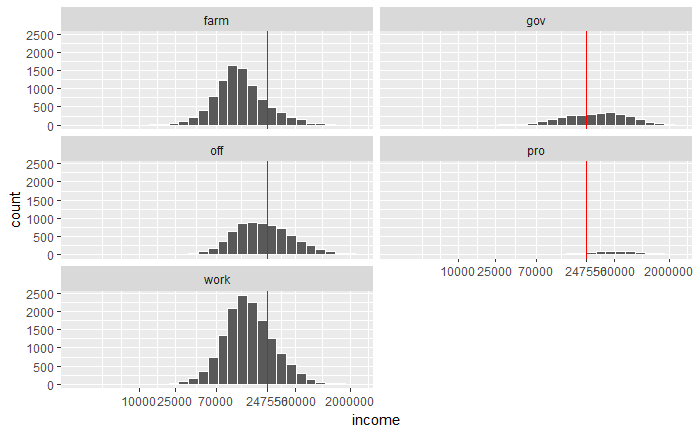

```r
ggplot(subset(fies, income != 0 &
                !is.na(head_class)),
       aes(income)) +
  geom_histogram(col=I("white")) +
  scale_x_continuous(trans = log10_trans(),
                     breaks = c(10000, 25000, 70000,
                                247556,
                                500000, 2000000),
                     limits = c(2000, 2500000)) +
  facet_wrap( ~ head_class, ncol = 2)  +
  geom_vline(data = subset(fies, !is.na(head_class)),
             aes(xintercept = mean(fies$income)),
             color = I("red"))
```

We go back to the overall income distribution but this time using our working class categories. We add the average income Php247k and we see that some groups are below the average line and other groups are above the average line.

## Income from Salaries

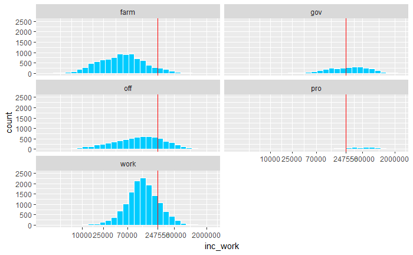

```r
ggplot(subset(fies, inc_work != 0 &
                !is.na(head_class)),
       aes(inc_work)) +
  geom_histogram(col=I("white"), fill = I("#00CCFF")) +
  scale_x_continuous(trans = log10_trans(),
                     breaks = c(10000, 25000, 70000,
                                247556,
                                500000, 2000000),
                     limits = c(2000, 2500000)) +
  scale_y_continuous(breaks = c(0, 500, 1000, 1500,
                               2000, 2500),
                     limits = c(0, 2500)) +
  facet_wrap( ~ head_class, ncol = 2)  +
  geom_vline(data = subset(fies, !is.na(head_class)),
             aes(xintercept = mean(fies$income)),
             color = I("red"))
```

If people relied from their salaries, the picture is the same. Farmers, Office and Workers are below the average line while Gov Employees and Professionals are above the average line.

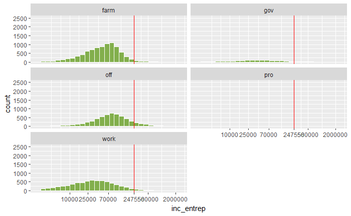

```r
ggplot(subset(fies, inc_entrep != 0 &
                !is.na(head_class)),
       aes(inc_entrep)) +
  geom_histogram(col=I("white"), fill = I("#82AF4C")) +
  scale_x_continuous(trans = log10_trans(),
                     breaks = c(10000, 25000, 70000,
                                247556,
                                500000, 2000000),
                     limits = c(2000, 2500000)) +
  scale_y_continuous(breaks = c(0, 500, 1000, 1500,
                               2000, 2500),
                     limits = c(0, 2500)) +
  facet_wrap( ~ head_class, ncol = 2)  +
  geom_vline(data = subset(fies, !is.na(head_class)),
             aes(xintercept = mean(fies$income)),
             color = I("red"))
```

If people relied solely on income from their business, All of them are below the Average line. But the graphs are different somehow but it is not clear from this view.

[output not shown]

[figure not shown]

```r
ggplot(subset(fies, inc_entrep != 0 &
                !is.na(head_class)),
       aes(inc_entrep)) +
  geom_histogram(col=I("white"), fill = I("#82AF4C")) +
  scale_x_continuous(trans = log10_trans(),
                     breaks = c(10000, 25000, 70000,
                                247556,
                                500000, 2000000),
                     limits = c(2000, 2500000)) +
  scale_y_continuous(breaks = c(0, 500, 1000, 1500,
                               2000, 2500),
                     limits = c(0, 2500)) +
  facet_wrap( ~ head_class, ncol = 2)  +
  geom_vline(data = subset(fies, !is.na(head_class)),
             aes(xintercept = mean(fies$income)),
             color = I("red"))
```

[figure not shown]